# R Tutorial: Summarizing relationships between two categorical variables

# Learning Objectives:

- Create a contingency table of counts and percentages by row/column
- Draw a block diagram
- Compute the Chi-square statistic
- Create a table of expected counts

# Example data

Read the “coffee.csv” file containing survey responses from 65 students about coffee consumption.

```r
coffee <- read.csv("coffee.csv")
```

Let’s examine the association between the categorical variables `gender` (Female, Male, or Prefer not to answer) and `drinkCoffee` (whether respondents drink coffee or not, Yes or No). First, we will exclude missing values from the data frame using the `na.omit` function. The new data frame will have 61 complete observations.

```r
coffee <- na.omit(coffee)
```

# 1 Contingency tables

### Counts

The `table(var1, var2, ...)` function creates a contingency table of counts. The first variable (`var1`) will form the rows of the table, and the second variable (`var2`) will form the columns.

```r
counts <- table(coffee$drinkCoffee, coffee$gender)
counts
```

```
##
##       Female Male Prefer not to answer
##   No      12    3                    0
##   Yes     31   13                    2
```

### Proportions

After creating the table object, you can compute row and column percentages with `prop.table(table, margin, ..)`

- **table**: table of counts created with `table()`
- **margin** (optional): `1` for row proportions, `2` for column proportions, or `c(1, 2)` for proportions of total (default)

```r
# Row proportions
prop.table(counts, margin = 1)
```

```
##
##           Female       Male Prefer not to answer
##   No  0.80000000 0.20000000           0.00000000
##   Yes 0.67391304 0.28260870           0.04347826
```

```r
# We multiply by 100 to convert proportions into percentages
(row_percent <- prop.table(counts, margin = 1)*100)
```

```
##
##          Female      Male Prefer not to answer
##   No  80.000000 20.000000             0.000000
##   Yes 67.391304 28.260870             4.347826
```

```r
# We can apply the round() function to improve the readability of our table
round(row_percent, digits=1)
```

```
##
##       Female Male Prefer not to answer
##   No    80.0 20.0                  0.0
##   Yes   67.4 28.3                  4.3
```

```r
# Column percentages
(col_percent <- prop.table(counts, margin = 2)*100)
```

```
##
##          Female      Male Prefer not to answer
##   No   27.90698  18.75000              0.00000
##   Yes  72.09302  81.25000            100.00000
```

### Row, Column, and grand totals

We can add row, column, and grand totals to the table using `addmargins(table, margin, ..)`

```r
# Add row/column totals to the table of counts
addmargins(counts)
```

```
##
##       Female Male Prefer not to answer Sum
##   No      12    3                    0  15
##   Yes     31   13                    2  46
##   Sum     43   16                    2  61
```

```r
# Add a new column with row totals (should sum to 100% in the row_percent table)
addmargins(row_percent, margin = 2)
```

```
##
##           Female       Male Prefer not to answer        Sum
##   No   80.000000  20.000000             0.000000 100.000000
##   Yes  67.391304  28.260870             4.347826 100.000000
```

```r
# Add a new crow with column totals (should sum to 100% in the col_percent table)
addmargins(col_percent, margin = 1)
```

```
##
##          Female      Male Prefer not to answer
##   No   27.90698  18.75000              0.00000
##   Yes  72.09302  81.25000            100.00000
##   Sum 100.00000 100.00000            100.00000
```

# 2 Block diagram

The function to create a block diagram (or side-by-side bar chart) is: `barplot(height, beside, legend.text, main, xlab, ylab, col, ...)`

- **height**: contingency table of counts or proportions representing heights of the bars (column labels will appear on the x-axis, and row labels will appear in the legend)
- **beside** (optional): `TRUE` for bars side-by-side (`FALSE` for stacked bars)
- **legend.text** (optional): `TRUE` to use the row names of your table as legend labels
- **args.legend** (optional): additional list of arguments to customize the legend (type `?legend` to learn more)
- **col** (optional): vector of colours the same length as the number of rows in your table of counts
- **main** (optional): title for plot
- **xlab** (optional): title for x-axis (horizontal axis)
- **ylab** (optional): title for y-axis (vertical axis)

Type `?barplot` in the console and press enter to see the documentation for this function.

We will create a block diagram of column percentages because we wish to compare `gender` (columns of our contingency table) with respect to the percentage of students who drink coffee.

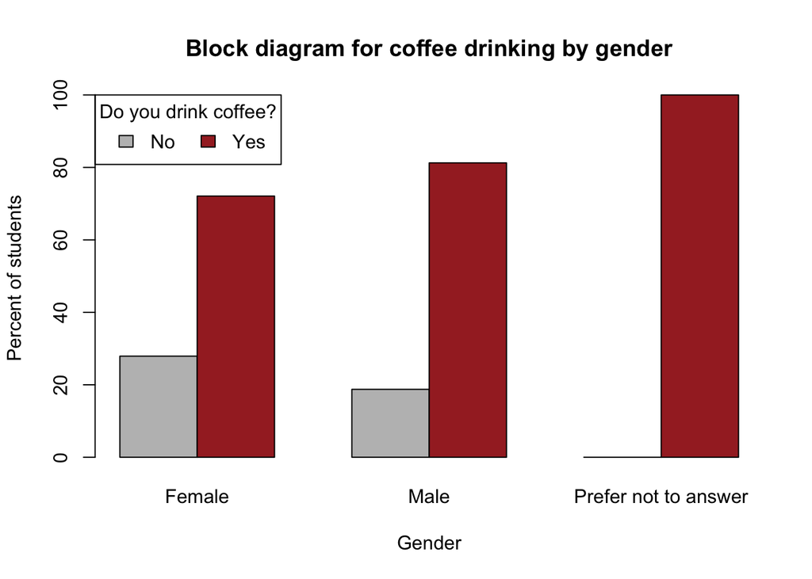

```r
barplot(height = col_percent,
        beside = TRUE,
        legend.text = TRUE,
        args.legend = list(x = "topleft", horiz = TRUE, title = "Do you drink coffee?"),
        col = c("grey", "brown"),
        xlab = "Gender",
        ylab = "Percent of students",
        main = "Block diagram for coffee drinking by gender")
```

By default, `barplot()` will plot the column labels (`gender` in this case) of the table on the x-axis. We can transpose the table (switch the row and column categories) using the `t()` function if we wish to plot row labels on the x-axis instead.

```r
# original table of column percentages
col_percent
```

```
##
##          Female      Male Prefer not to answer
##   No   27.90698  18.75000              0.00000
##   Yes  72.09302  81.25000            100.00000
```

```r
# transposed table of column percentages
t(col_percent)
```

```
##
##                               No       Yes
##   Female                27.90698  72.09302
##   Male                  18.75000  81.25000
##   Prefer not to answer   0.00000 100.00000
```

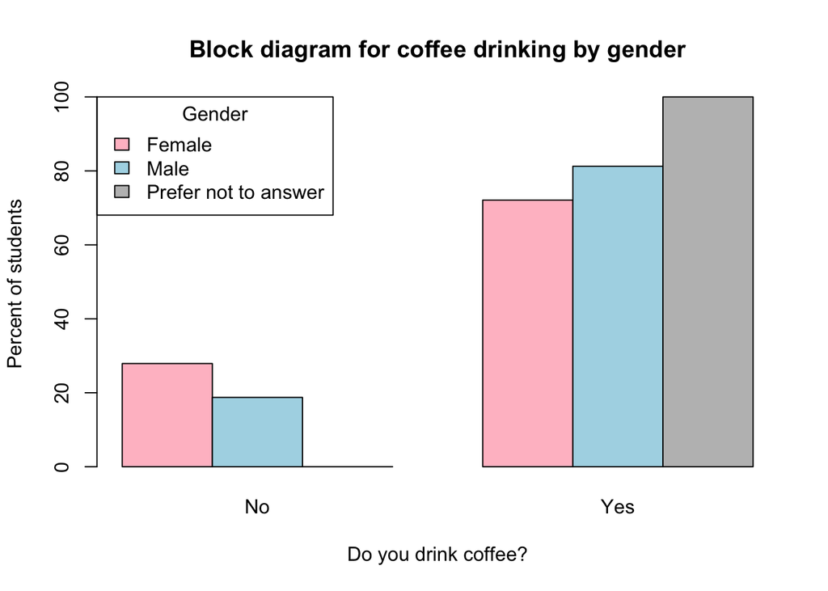

```r
# block diagram with drinkCoffee on the x-axis
barplot(height = t(col_percent),
        beside = TRUE,
        legend.text = TRUE,
        args.legend = list(x = "topleft", horiz = FALSE, title = "Gender"),
        col = c("pink", "lightblue", "grey"),
        xlab = "Do you drink coffee?",
        ylab = "Percent of students",
        main = "Block diagram for coffee drinking by gender")
```

Note that both block diagrams show the same column percentages, but there may be scenarios where you wish to show row percentages. You can set the `height` argument in `barplot()` to the row percentages table.

# 3 Chi-square test

The function to perform a chi-square test is: `chisq.test(x, y, ...)`

- **x**: contingency table of counts, or a vector representing the first categorical variable
- **y** (optional): vector representing the second categorical variable (ignored if x is a table of counts)

```r
# we can use the table of counts we already created
chisq.test(counts)
```

```
##
##  Pearson's Chi-squared test
##
## data:  counts
## X-squared = 1.2016, df = 2, p-value = 0.5484
```

```r
# we can also list the two categorical variables (will give the same result)
chisq.test(coffee$gender, coffee$drinkCoffee)
```

```
## Warning in chisq.test(coffee$gender, coffee$drinkCoffee): Chi-squared
## approximation may be incorrect
```

```
##
##  Pearson's Chi-squared test
##
## data:  coffee$gender and coffee$drinkCoffee
## X-squared = 1.2016, df = 2, p-value = 0.5484
```

This function will print the chi-square statistic ($\chi^2 = 1.2016$) and degrees of freedom ($df=2$). A warning may appear if the expected counts are not all at least 5.

### Observed and expected counts

You can also save the result of the chi-square test as an object and extract more information, including observed and expected counts.

```r
# we will save the results as an R object called "test"
test <- chisq.test(counts)

# chi-square statistic
test$statistic
```

```
## X-squared
##  1.201574
```

```r
# observed counts
(o <- test$observed)
```

```
##
##       Female Male Prefer not to answer
##   No      12    3                    0
##   Yes     31   13                    2
```

```r
# expected counts
(e <- test$expected)
```

```
##
##         Female      Male Prefer not to answer
##   No  10.57377  3.934426            0.4918033
##   Yes 32.42623 12.065574            1.5081967
```

```r
# individual cell contributions to chi-square statistics
(cont <- (o-e)^2/e)
```

```
##
##           Female       Male Prefer not to answer
##   No  0.19237514 0.22192623           0.49180328
##   Yes 0.06273102 0.07236725           0.16037063
```

```r
# chi-square statistic (computed by hand, should be the same as "test$statistic")
sum(cont)
```

```
## [1] 1.201574
```

# Exercises

For the following questions, examine the relationship between `gender` and `timeCoffee`.

1. Create a contingency table of counts with `gender` in the rows of the table and `timeCoffee` in the columns of the table. Exclude respondents with blank values ("") for `timeCoffee` and “Prefer not to answer” for `gender`.
2. Compute row percentages for your table.
3. Create a block diagram that displays row percentages.
4. Compute the chi-square statistic.
5. Create a table of expected counts.

# Solutions

1. Contingency table

```r
# 1. Contingency table

# exclude blanks and prefer not answer
not_blank <- coffee$timeCoffee != ""
not_no_answer <- coffee$gender != "Prefer not to answer"
clean_data <- coffee[not_blank & not_no_answer, ]

# table of counts
(counts <- table(clean_data$gender, clean_data$timeCoffee))
```

```
##
##          Afternoon Evening Morning Night
##   Female        11       7      20     1
##   Male           5       1       7     1
```

2. Row percentages

```r
# 2. Row percentages
row_percent <- prop.table(counts, margin=1)*100
round(row_percent, 1)
```

```
##
##          Afternoon Evening Morning Night
##   Female      28.2    17.9    51.3   2.6
##   Male        35.7     7.1    50.0   7.1
```

3. Block diagram

`timeCoffee` on x-axis

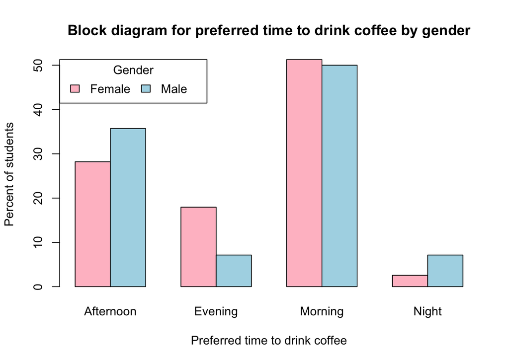

```r
# 3. Block diagram
barplot(height = row_percent,
        beside = TRUE,
        legend.text = TRUE,
        args.legend = list(x = "topleft", horiz = TRUE, title = "Gender"),
        col = c("pink", "lightblue"),
        xlab = "Preferred time to drink coffee",
        ylab = "Percent of students",
        main = "Block diagram for preferred time to drink coffee by gender")
```

`gender` on x-axis

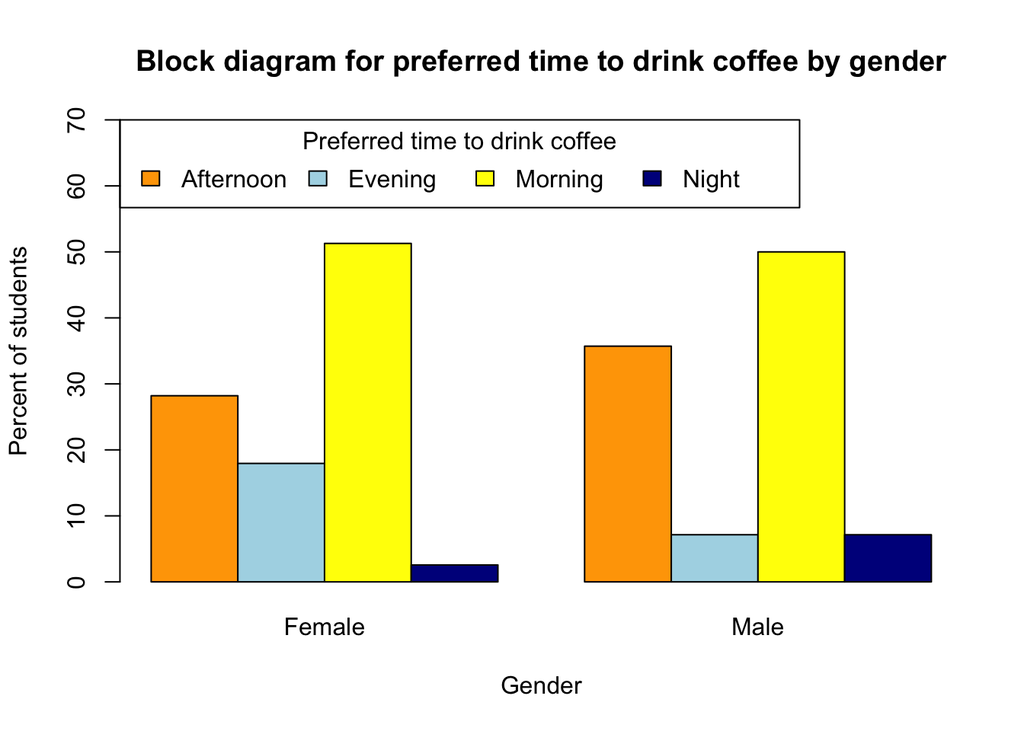

```r
barplot(height = t(row_percent),
        beside = TRUE,
        legend.text = TRUE,
        args.legend = list(x = "topleft", horiz = TRUE, title = "Preferred time to drink coffee"),
        #col = c("yellow", "orange", "lightblue", "darkblue"),
        col = c("orange", "lightblue", "yellow", "darkblue"),
        ylim = c(0, 70), ## allow extra space for legend by setting larger y-axis limit
        xlab = "Gender",
        ylab = "Percent of students",
        main = "Block diagram for preferred time to drink coffee by gender")
```

Since `timeCoffee` is ordinal, we should arrange the time categories by time of day.

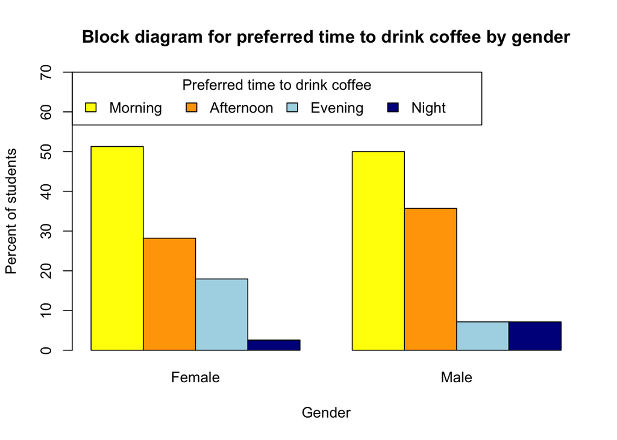

```r
# change the category ordering directly in the row_percent table
col_order <- c("Morning", "Afternoon", "Evening", "Night")
ordered_row_percent <- row_percent[ , col_order]

# gender on x-axis
barplot(height = t(ordered_row_percent),
        beside = TRUE,
        legend.text = TRUE,
        args.legend = list(x = "topleft", horiz = TRUE, title = "Preferred time to drink coffee"),
        col = c("yellow", "orange", "lightblue", "darkblue"),
        ylim = c(0, 70), ## allow extra space for legend by setting larger y-axis limit
        xlab = "Gender",
        ylab = "Percent of students",
        main = "Block diagram for preferred time to drink coffee by gender")
```

4. Chi-square statistic: $\chi^2 = 1.565$

```r
# 4. Chi-square
(test <- chisq.test(counts))
```

```
##
##  Pearson's Chi-squared test
##
## data:  counts
## X-squared = 1.565, df = 3, p-value = 0.6673
```

5. Table of expected counts

```r
# 5. Expected counts
round(test$expected, 1)
```

```
##
##          Afternoon Evening Morning Night
##   Female      11.8     5.9    19.9   1.5
##   Male         4.2     2.1     7.1   0.5
```